# Pierwszy projekt zaliczeniowy

Statystyczna analiza danych 2020/2021

Joanna Kęczkowska

07.05.2021

Celem zadania jest statystyczna analiza danych znajdujących się w pliku people.tab. Dane: Są to dane symulowane; opisują wiek (zmienna age), wagę (weight), wzrost (height), płeć (gender), stan cywilny (married), liczbę dzieci (number_of_kids), posiadane zwierzę domowe (pet) oraz miesięczne wydatki (expenses) pewnych osób. We wszystkich zadaniach poniżej zmienna expenses jest zmienną objaśnianą (zależną), a pozostałe zmienne są zmiennymi objaśniającymi (niezależnymi).

# 1 Wczytywanie danych

**1.** **Wczytaj dane, obejrzyj je i podsumuj w dwóch-trzech zdaniach.** Pytania pomocnicze: ile jest obserwacji, ile zmiennych ilościowych, a ile jakościowych? Czy są zależności w zmiennych objaśniających (policz i zaprezentuj na wykresach korelacje pomiędzy zmiennymi ilościowymi, a także zbadaj zależność zmiennych jakościowych). Skomentuj wyniki. Czy występują jakieś braki danych?

```r
df <- read.delim("peopletab.txt", header = TRUE, sep = '\t')
sprintf("Dane zawierają %d obserwacji i %d cech", dim(df)[1], dim(df)[2])
```

```
## [1] "Dane zawierają 500 obserwacji i 8 cech"
```

```r
summary(df)
```

```
##       age            weight           height         gender
##  Min.   :17.00   Min.   : 19.40   Min.   :113.6   Length:500
##  1st Qu.:33.00   1st Qu.: 57.60   1st Qu.:155.6   Class :character
##  Median :39.00   Median : 66.60   Median :169.0   Mode  :character
##  Mean   :39.48   Mean   : 66.39   Mean   :168.2
##  3rd Qu.:45.00   3rd Qu.: 75.30   3rd Qu.:180.1
##  Max.   :72.00   Max.   :107.20   Max.   :235.2
##   married        number_of_kids      pet               expenses
##  Mode :logical   Min.   :0.000   Length:500         Min.   :-685.68
##  FALSE:327       1st Qu.:0.750   Class :character   1st Qu.:  74.51
##  TRUE :173       Median :1.000   Mode  :character   Median : 402.22
##                  Mean   :1.558                      Mean   : 478.60
##                  3rd Qu.:2.000                      3rd Qu.: 802.72
##                  Max.   :6.000                      Max.   :3503.90
```

## 1.1 Podsumowanie i faktoryzacja zmiennych jakościowych

Dane zawierają **500 obserwacji**.  
**Zmienne ilościowe**: ‘age’, ‘weight’, ‘height’, ‘expenses’.  
**Zmienne jakościowe**: ‘gender’, ‘married’, ‘pet’, ‘number_of_kids’.  
Niepokojące są ujemne wartości w cesze ‘expenses’, jak również factor ‘other’ w cesze ‘gender’. Wartość ‘none’ w cesze ‘pet’ interpretuję jako nieposiadanie zwierzęcia. Wydaje się że zestaw danych nie ma braków - nie ma pustych komórek.

**Faktoryzacja zmiennych jakościowych**:

```r
df$gender <- factor(df$gender)
df$pet <- factor(df$pet)
df$married <- factor(df$married)
df$number_of_kids <- factor(df$number_of_kids)
summary(df)
```

```
##       age            weight           height        gender     married
##  Min.   :17.00   Min.   : 19.40   Min.   :113.6   man  :223   FALSE:327
##  1st Qu.:33.00   1st Qu.: 57.60   1st Qu.:155.6   other: 38   TRUE :173
##  Median :39.00   Median : 66.60   Median :169.0   woman:239
##  Mean   :39.48   Mean   : 66.39   Mean   :168.2
##  3rd Qu.:45.00   3rd Qu.: 75.30   3rd Qu.:180.1
##  Max.   :72.00   Max.   :107.20   Max.   :235.2
##
##  number_of_kids       pet         expenses
##  0:125          cat     :105   Min.   :-685.68
##  1:161          dog     :100   1st Qu.:  74.51
##  2: 99          ferret  : 54   Median : 402.22
##  3: 63          hedgehog: 54   Mean   : 478.60
##  4: 35          none    :187   3rd Qu.: 802.72
##  5: 11                         Max.   :3503.90
##  6:  6
```

## 1.2 Korelacja zmiennych ilościowych

Współczynnik korelacji r jest liczbą pomiędzy –1 i 1, która określa, w jakim stopniu dwie zmienne są współzależne. Wartość r = 0 oznacza, że nie ma żadnego powiązania, a wartość 1 lub –1 oznacza idealne powiązanie. Znak współczynnika korelacji wskazuje, czy zmienne są skorelowane dodatnio (większe wartości w jednej zmiennej pokrywają się z większymi wartościami w drugiej), czy też ujemnie (większe wartości w jednej zmiennej pokrywają się z mniejszymi wartościami w drugiej).

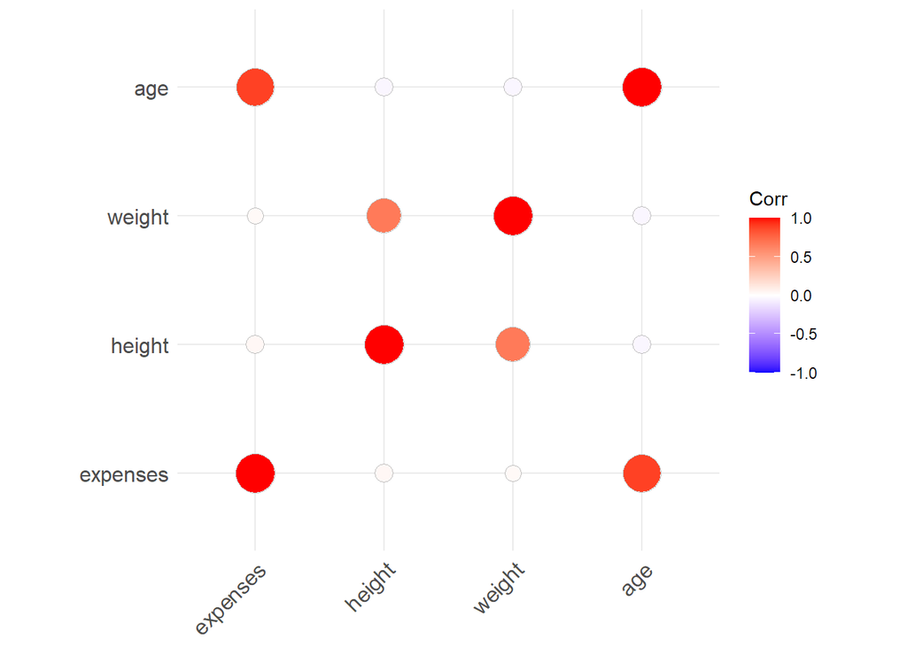

```r
library(ggcorrplot)
numerical <- df[c("expenses", "height", "weight", "age")]
categorial <- df[c("married", "gender", "pet", "number_of_kids")]

corr <- round(cor(numerical), 2)

ggcorrplot(corr, method = "circle")
```

Zgodnie z intuicją **wiek jest dodatnio skorelowany z wydatkami** i **wzrost jest dodatnio skorelowany z wagą**.

## 1.3 Korelacja zmiennych jakościowych

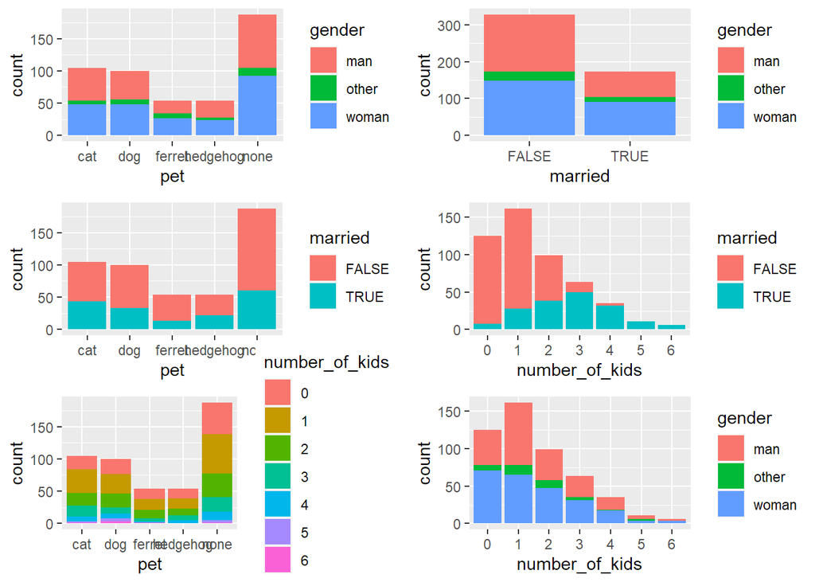

```r
p1 <- ggplot(df, aes(fill=gender, x=pet)) + geom_bar(position="stack")
p2 <- ggplot(df, aes(fill=gender, x=married)) + geom_bar(position="stack")
p3 <- ggplot(df, aes(fill=married, x=pet)) + geom_bar(position="stack")
p4 <- ggplot(df, aes(fill=married, x=number_of_kids)) + geom_bar(position="stack")
p5 <- ggplot(df, aes(fill=number_of_kids, x=pet)) + geom_bar(position="stack")
p6 <- ggplot(df, aes(fill=gender, x=number_of_kids)) + geom_bar(position="stack")
grid.arrange(p1, p2, p3, p4, p5, p6, nrow=3)
```

**Liczba dzieci zależy od małżeństwa**(rząd 2 kolumna 2). W innych nie widać istotnych korelacji, ale można dla pewności przeprowadzić test zależności ${\chi}^2$:

Dla danej komórki wartość oczekiwana: $e = \frac{row.sum*col.sum}{grand.total}$  
Chi-square statistic: ${\chi}^2 = \sum \frac{(o-e)^2}{e}$, gdzie o - obserwacja, e - wartość oczekiwana

Hipoteza zerowa $H_0$: Zmienne są **niezależne**.  
Hipoteza alternatywna $H_1$: Zmienne są **zależne**.

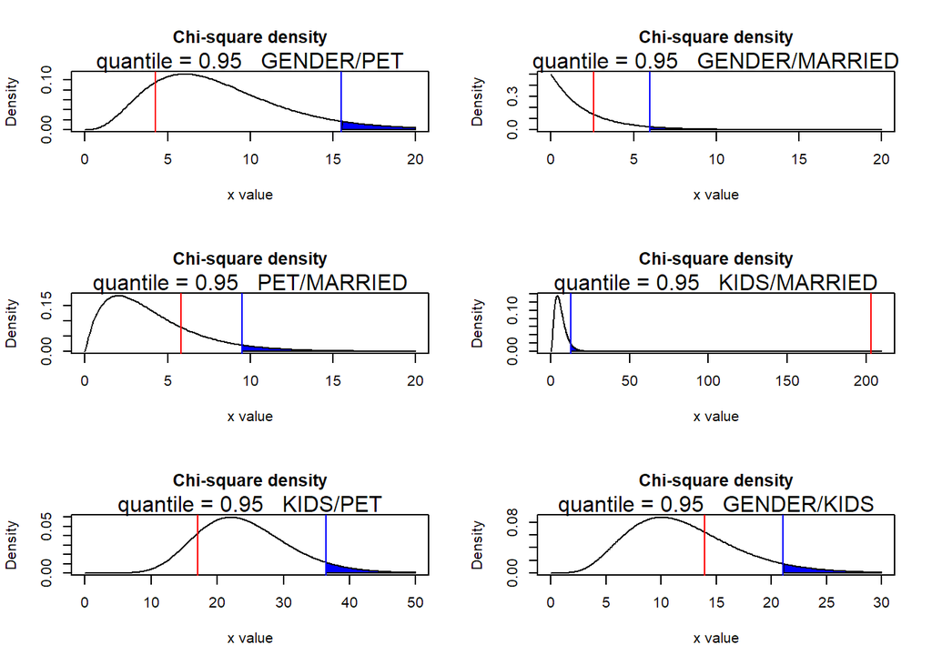

```r
#funkcja do testowania korelacji zmiennych jakościowych
#przyjmuje dwie kolumny zmiennych kategorycznych, które zamienia na tablicę wielodzielczą

testchi <- function(feature1, feature2, sq = 20, t = ' ', alpha = 0.05) {
  TAB <- table(feature1, feature2)
  total <- sum(TAB)

  n <- nlevels(feature1)
  m <- nlevels(feature2)

  sumRows <- margin.table(TAB, 1) #rows
  sumCols <- margin.table(TAB, 2) #columns

  sumRows <- as.vector(sumRows)
  sumCols <- as.vector(sumCols)

  exp <- matrix(rep(0, n * m), nrow = n, ncol = m)
  exp[] <- 0L
  for (i in 1:n) {
    exp[i,] <- sumRows[i] * sumCols / total
  }

  Tab <- data.frame(TAB)
  obs <- matrix(Tab[["Freq"]], nrow = n, ncol = m)

  chi_sq <- sum((obs - exp)^2 / exp) #test statistic
  df <- (nrow(obs) - 1) * (ncol(obs) - 1) #deg of freedom
  pval <- pchisq(chi_sq, df, lower.tail = FALSE)  #right-tailed

  quantile <- qchisq(alpha, df, lower.tail = FALSE) #quantile of chi-square distribution

  x <- seq(0, sq, by = 0.1)
  chi_dense <- dchisq(x, df)

  plot(x, chi_dense, type = 'l', xlab = "x value",
       ylab = "Density", main = "Chi-square density")

  i <- x >= quantile
  lines(x, chi_dense)
  polygon(c(quantile, x[i], sq), c(0, chi_dense[i], 0), col = "blue")

  area <- pchisq(quantile, df, lower.tail = TRUE)
  result <- paste("quantile =", signif(area, digits = 3), " ", t)
  mtext(result, 3)
  abline(v = chi_sq, col = "red")
  abline(v = quantile, col = "blue")

  c <- list(chi_sq, pval, quantile)
  return(c)

}
par(mfrow = c(3, 2))
gp <- testchi(df$gender, df$pet, t = "GENDER/PET")
gm <- testchi(df$gender, df$married, t = "GENDER/MARRIED")
pm <- testchi(df$pet, df$married, t = "PET/MARRIED")
nm <- testchi(df$number_of_kids, df$married, sq = 210, t = "KIDS/MARRIED")
np <- testchi(df$number_of_kids, df$pet, t = "KIDS/PET", sq = 50)
gn <- testchi(df$gender, df$number_of_kids, t = "GENDER/KIDS", sq = 30)
```

```r
sprintf("GENDER/PET, test statistic = %f , p-value = %f, confidece interval = [-infinity, %f]", gp[[1]], gp[[2]], gp[[3]])
```

```
## [1] "GENDER/PET, test statistic = 4.264540 , p-value = 0.832502, confidece interval = [-infinity, 15.507313]"
```

```r
sprintf("GENDER/MARRIED, test statistic = %f , p-value = %f, confidece interval = [-infinity, %f]", gm[[1]], gm[[2]], gm[[3]])
```

```
## [1] "GENDER/MARRIED, test statistic = 2.597089 , p-value = 0.272929, confidece interval = [-infinity, 5.991465]"
```

```r
sprintf("PET/MARRIED, test statistic = %f , p-value = %f, confidece interval = [-infinity, %f]", pm[[1]], pm[[2]], pm[[3]])
```

```
## [1] "PET/MARRIED, test statistic = 5.806971 , p-value = 0.214035, confidece interval = [-infinity, 9.487729]"
```

```r
sprintf("KIDS/MARRIED, test statistic = %f , p-value = %f, confidece interval = [-infinity, %f]", nm[[1]], nm[[2]], nm[[3]])
```

```
## [1] "KIDS/MARRIED, test statistic = 203.501380 , p-value = 0.000000, confidece interval = [-infinity, 12.591587]"
```

```r
sprintf("KIDS/PET, test statistic = %f , p-value = %f, confidece interval = [-infinity, %f]", np[[1]], np[[2]], np[[3]])
```

```
## [1] "KIDS/PET, test statistic = 17.076893 , p-value = 0.845364, confidece interval = [-infinity, 36.415029]"
```

```r
sprintf("GENDER/KIDS, test statistic = %f , p-value = %f, confidece interval = [-infinity, %f]", gn[[1]], gn[[2]], gn[[3]])
```

```
## [1] "GENDER/KIDS, test statistic = 13.950817 , p-value = 0.303860, confidece interval = [-infinity, 21.026070]"
```

Czerwoną linią zaznaczono test statystyczny, niebieską kwantyl na poziomie istotności 5%, a niebieski obszar to obszar krytyczny.  
Jedyne dwie skorelowane zmienne jakościowe to ‘number_of_kids’ i ‘married’ (na co wskazywał też wykres słupkowy)- statystyka testowa wpada do obszaru krytycznego (wykres 2 rząd 2 kolumna). W przypadku pozostałych par zmiennych nie mamy podstawy do odrzucenia hipotezy zerowej. Żadne dwie inne zmienne nie są skorelowane.

# 2 Wykresy

**2.** **Podsumuj dane przynajmniej trzema różnymi wykresami.** Należy przygotować: **a)** wykres typu scatter-plot (taki jak na wykładzie 6, slajd 3) dla wszystkich zmiennych objaśniających ilościowych i zmiennej objaśnianej. **b)** Wykresy typu pudełkowy (boxplot) dla jednej wybranej zmiennej ilościowej. **c)** Wykres typu słupkowy (barplot) dla jednej wybranej zmiennej jakościowej. Dodatkowe wykresy wg własnej inwencji (np. histogram, punktowy, liniowy, mapa ciepła…).

## 2.1 Scatter-plot dla wszystkich zmiennych ilościowych

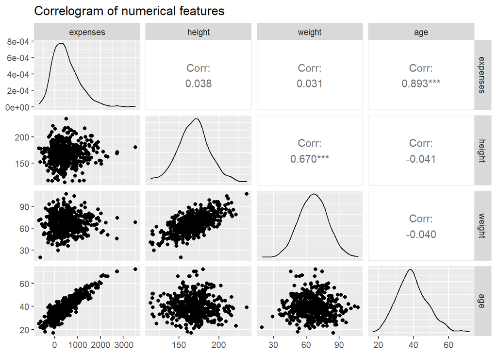

```r
library(GGally)

ggpairs(numerical, title = "Correlogram of numerical features")
```

Trochę inny wykres od ‘ggcorrplot(corr, method = “circle”)’, ale prowadzący do tych samych wniosków: dodatnia korelacja wzrostu z wagą (0.67) i dodatnia korelacja wieku z wydatkami (0.893).

## 2.2 BoxPlot dla zmiennej ‘expenses’:

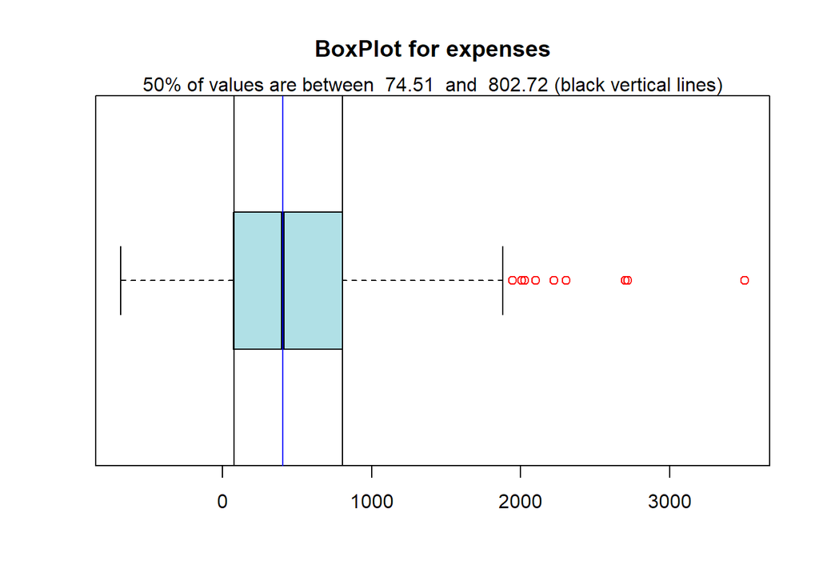

```r
expenses <- df$expenses
quantiles <- unname(quantile(expenses))
boxplot(expenses, horizontal = TRUE, col = "powderblue", outcol = "red", main = "BoxPlot for expenses")


result <- paste("50% of values are between ", round(quantiles[2], 2), " and ", round(quantiles[4], 2), "(black vertical lines)")
mtext(result, 3)
abline(v = quantiles[4], col = "black") #quantile 75%
abline(v = quantiles[2], col = "black") #quantile 25%
abline(v = median(expenses), col="blue") #median
```

```r
sprintf("Kwantyl 3/4: %f, kwantyl 1/4: %f, mediana: %f", quantiles[4], quantiles[2], median(expenses))
```

```
## [1] "Kwantyl 3/4: 802.721954, kwantyl 1/4: 74.514280, mediana: 402.219536"
```

Obserwacje odstające zaznaczono na czerwono.

## 2.3 Rozkład zmiennej ‘number_of_kids’ - wykres słupkowy:

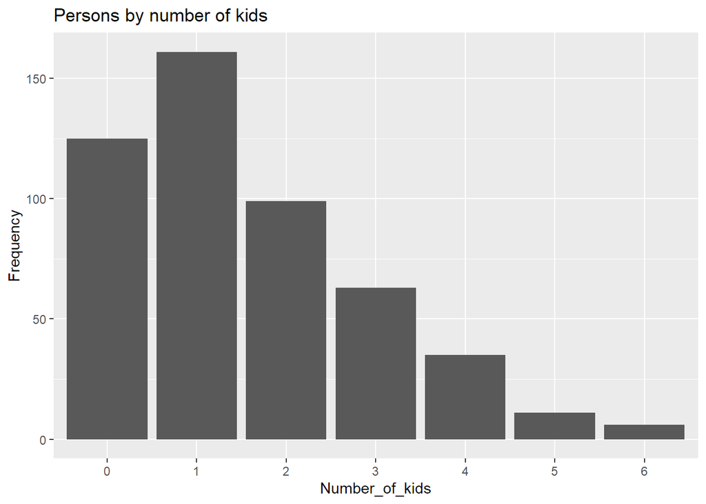

```r
library(ggplot2)

ggplot(df, aes(x = number_of_kids)) +
  geom_bar() +
  labs(x = "Number_of_kids",
       y = "Frequency",
       title = "Persons by number of kids")
```

## 2.4 Wykres punktowy dla zmiennej ‘expenses’ i ‘age’ - dodatkowe wykresy:

Wykres punktowy zmiennej ‘expenses’ w zależności od ‘age’ z zaznaczoną kolorem ‘gender’:

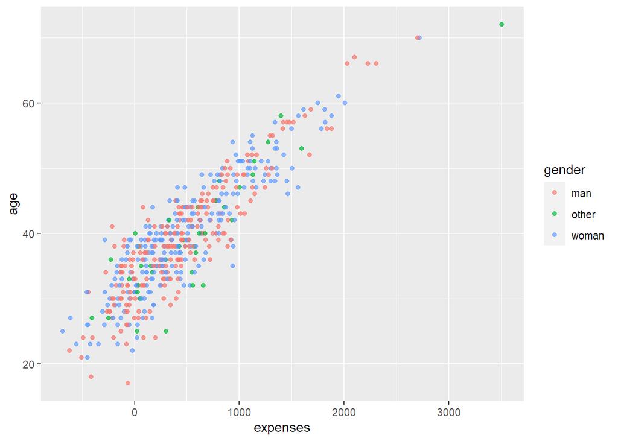

```r
ggplot(df, aes(x = expenses, y = age, color = gender)) +
  geom_point(alpha = 0.7) +
  scale_size(range = c(1.4, 19))
```

## 2.5 Wzrost w zależności od płci - dodatkowe wykresy:

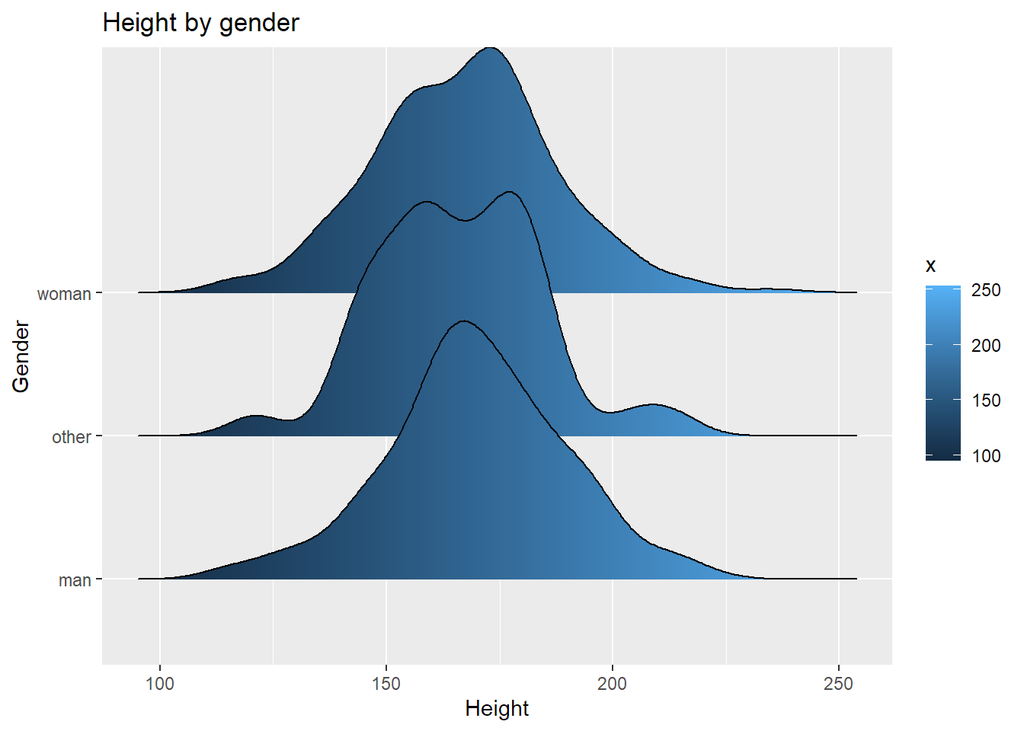

```r
hW <- df[df$gender=="woman",]$height
hM <- df[df$gender=="man",]$height
ggplot(df, aes(x = height, y = gender, fill = stat(x))) +
  geom_density_ridges_gradient() +
  labs(x = "Height",
       y = "Gender",
       title = "Height by gender")
```

# 3 Testowanie hipotez dla wartości średniej i mediany

**3.** **Policz p-wartości dla hipotez o wartości średniej m = 170 i medianie me = 165 (cm) dla zmiennej wzrost.** Wybierz statystykę testową dla alternatywy lewostronnej, **podaj założenia**, z jakich korzystałeś i skomentuj czy wydają Ci się uprawnione.

## 3.1 Jednopróbkowy test t dla średniej

Jednopróbkowy test t: $t=\frac{\overline{X}-\mu}{\sigma}\dot.\sqrt{n}$, gdzie $\overline{X}$ - średnia próby, $n$ - liczba obserwacji, $\sigma$ - odchylenie standardowe

Hipoteza zerowa H0: $\mu = 170$  
Hipoteza alternatywna H1: $\mu < 170$ (alternatywa lewostronna)  
Założenia: (zmienna ilościowa, rozkład normalny próby, niezależne obserwacje)  
Poziom istotności: 0.05

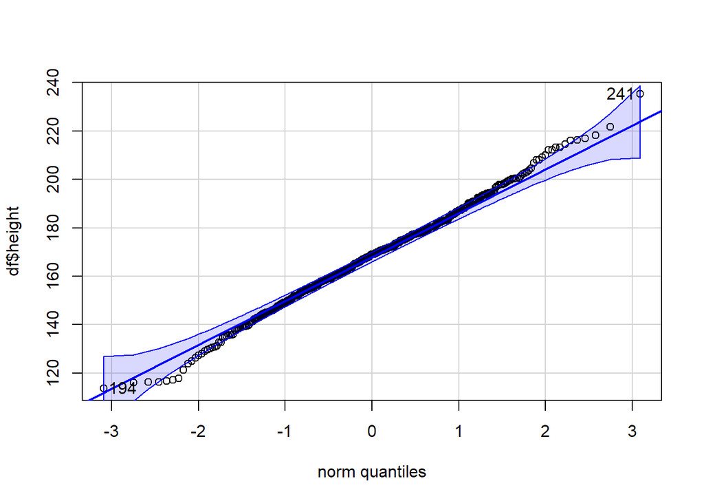

```
## [1] 241 194
```

```r
qqPlot(df$height)
```

```r
shaptest <- shapiro.test(df$height)
shaptest
```

```
##
##  Shapiro-Wilk normality test
##
## data:  df$height
## W = 0.99662, p-value = 0.3778
```

P-value jest większe niż 0.05 co w połączeniu z analizą wykresu qqPlot() implikuje, że zmienna nie różni się istotnie od rozkładu normalnego. Innymi słowy możemy założyć rozkład normalny. Oczywiście obserwacje są niezależne - jedna obserwacja nie dostarcza informacji o drugiej - obserwacje to różne osoby.

```r
alpha <- 0.05
m <- 170
me <- 165
height <- df$height
n <- length(height)

test <- (mean(height) - m) / sd(height) * sqrt(n)
def <- n - 1

quantile <- qt(alpha, def) #left-tailed
pval <- pt(test, def)

x <- seq(-5, 5, by = 0.01)
t_dense <- dt(x, n - 1)

plot(x, t_dense, type = 'l', xlab = "x value",
     ylab = "Density", main = "Student's density")

i <- x <= quantile
lines(x, t_dense)

polygon(c(-5, quantile, x[i]), c(0, t_dense[i], 0), col = "blue")
sprintf("test statistic = %f , p-value = %f, confidence interval = [%f, infinity]", test, pval, quantile)
```

```
## [1] "test statistic = -2.069917 , p-value = 0.019487, confidence interval = [-1.647913, infinity]"
```

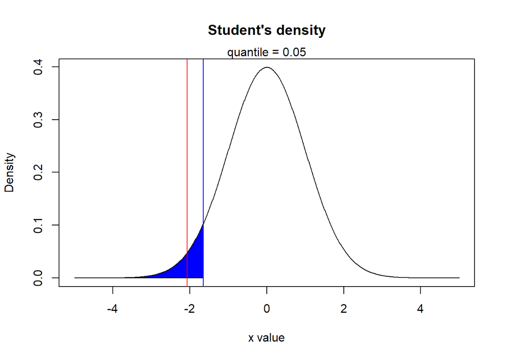

```r
area <- pt(quantile, def)
result <- paste("quantile =", signif(area, digits = 3))
mtext(result, 3)
abline(v = test, col = "red")
abline(v = quantile, col = "blue")
```

```r
if (alpha > pval) {
  print("H0 rejected.")
}else {
  print("There is not enough evidence to reject H_0")
}
```

```
## [1] "H0 rejected."
```

Statystyka testowa (czerwona linia) wpada do obszaru krytycznego (zaznaczonego na niebiesko) dlatego odrzucamy hipotezę zerową na rzecz alternatywnej, czyli $\mu < 170$.

## 3.2 Test Wilcoxona dla mediany

Hipoteza zerowa $H_0$: $m = 165$  
Hipoteza alternatywna $H_1$: $m < 165$ (alternatywa lewostronna)  
Założenia: (zmienna ilościowa, niezależne obserwacje)  
Poziom istotności: 0.05

```r
heightFrame <- as.data.frame(t(height))
rep <- as.data.frame(t(rep(165, length(height))))
heightFrame <- rbind(heightFrame, heightFrame - rep) #differences between 165
#heightFrame <- rbind(heightFrame, sign(heightFrame - rep))
heightFrame <- rbind(heightFrame, abs(heightFrame[2,]))

vec <- as.numeric(heightFrame[3,])
heightFrame <- rbind(heightFrame, rank(vec))

if (sum(heightFrame[2,] == 0) == 0) {
  n <- length(vec)
  posRanks <- sum(heightFrame[4, heightFrame[2,] > 0])
  negRanks <- sum(heightFrame[4, heightFrame[2,] < 0])
  if (posRanks + negRanks == n * (n+1)/2) {
    W <- min(posRanks, negRanks)
    m <- n * (n + 1) / 4
    sd <- n * (n + 1) * (2 * n + 1) / 24
    un <- as.numeric(heightFrame[4,])
    t <- length(un[un %in% un[duplicated(un)]]) # = 0
    tiedRanks <- (t^3 - t) / 48 # = 0
    zscore <- (W - m) / sqrt(sd - tiedRanks)
  }
}
quantile <- qnorm(alpha)
pval <- pnorm(zscore)

x <- seq(-5, 5, by = 0.01)
density <- dnorm(x)

plot(x, density, type = 'l', xlab = "x value",
     ylab = "Density", main = "Gaussian density")

i <- x <= quantile
lines(x, density)

polygon(c(-5, quantile, x[i]), c(0, density[i], 0), col = "blue")
sprintf("W = %f, test statistic = %f , p-value = %f, confidece interval = [%f, infinity]", W, zscore, pval, quantile)
```

```
## [1] "W = 50834.500000, test statistic = -3.649839 , p-value = 0.000131, confidece interval = [-1.644854, infinity]"
```

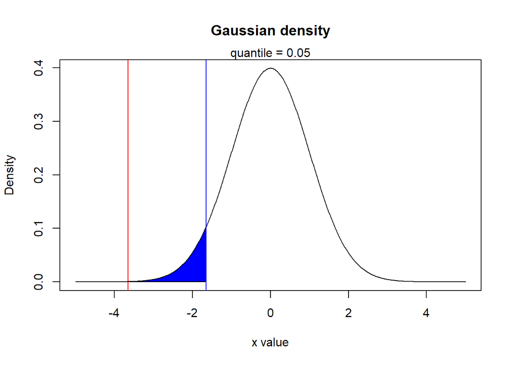

```r
area <- pnorm(quantile)
result <- paste("quantile =", signif(area, digits = 3))
mtext(result, 3)
abline(v = zscore, col = "red")
abline(v = quantile, col = "blue")
```

```r
if (alpha > pval) {
  print("H0 rejected.")
}else {
  print("There is not enough evidence to reject H_0")
}
```

```
## [1] "H0 rejected."
```

Odrzucamy hipotezę zerową - statystyka testowa wpada do obszaru krytycznego (wykres) - na rzecz hipotezy alternatywnej, czyli $m < 165$.

We wbudowanym teście jest tylko W i p-value:

```r
wilcox.test(rep(165, length(height))-height, alternative = "less")
```

```
##
##  Wilcoxon signed rank test with continuity correction
##
## data:  rep(165, length(height)) - height
## V = 50835, p-value = 0.0001324
## alternative hypothesis: true location is less than 0
```

# 4 Dwustronne przedziały ufności dla zmiennej wiek

**4.** **Policz dwustronne przedziały ufności na poziomie 0.99 dla zmiennej wiek dla następujących parametrów rozkładu:**  
1. średnia i odchylenie standardowe;  
2. kwantyle 1/4, 2/4 i 3/4.  
Podaj założenia, z jakich korzystałeś i skomentuj czy wydają Ci się uprawnione.

## 4.1 Przedziały dla średniej i odchylenia standardowego

**Studentyzowany przedział ufności**:  
$\left(\bar{X} - \frac {t(1-\alpha/2, n-1)}{\sqrt{n}}\hat{S}, \bar{X} + \frac{t(1-\alpha/2, n-1)}{\sqrt{n}}\hat{S}\right)$ gdzie $\bar{X}$ to średnia, $\hat{S}$ to pierwiastek z *nieobciążonego* estymatora wariancji, a $t(1-\alpha/2, n-1)$ to kwantyl na poziomie $1-\alpha/2$ dla rozkładu t Studenta o $n-1$ stopniach swobody.  
**Asymptotyczny przedział ufności**:  
$\left( \bar{X} - \frac{q(1-\alpha/2)}{\sqrt{n}}\hat{S}, \bar{X} + \frac{q(1-\alpha/2)}{\sqrt{n}}\hat{S} \right)$ gdzie $q(1-\alpha/2)$ jest kwantylem na poziomie $1 - \alpha/2$ ze standardowego rozkładu normalnego.  
Założenia: (rozkład normalny)

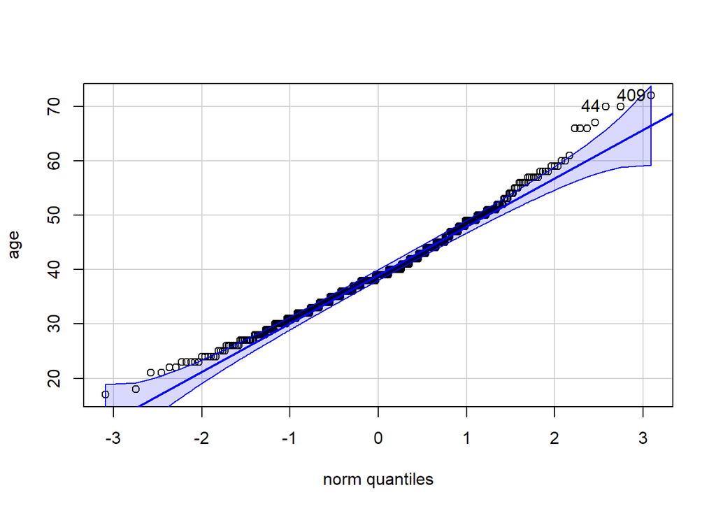

```
## [1] 409  44
```

```r
alpha <- 0.01
#ocena czy zmienna age ma rozkład normalny
age <- df$age
qqPlot(age)
```

```r
n <- length(age)
shapiro.test(age)
```

```
##
##  Shapiro-Wilk normality test
##
## data:  age
## W = 0.98179, p-value = 6.589e-06
```

```r
rightstud <- mean(age) + 1 / sqrt(n) *
  sd(age) *
  qt(1 - alpha / 2, (n - 1))
leftstud <- mean(age) - 1 / sqrt(n) *
  sd(age) *
  qt(1 - alpha / 2, (n - 1))

rightasympt <- mean(age) + (qnorm(1 - alpha / 2)) / sqrt(n) * sd(age)
leftasympt <- mean(age) - (qnorm(1 - alpha / 2)) / sqrt(n) * sd(age)

sprintf("Studentyzowany: (%f, %f)", leftstud, rightstud)
```

```
## [1] "Studentyzowany: (38.446003, 40.521997)"
```

```r
sprintf("Asymptotyczny: (%f, %f)", leftasympt, rightasympt)
```

```
## [1] "Asymptotyczny: (38.449973, 40.518027)"
```

## 4.2 Przedziały dla kwantyli 1/4, 1/2, 3/4

```r
lv <- levels(quantcut(age, q = seq(0, 1, 1/4)))
lv
```

```
## [1] "[17,33]" "(33,39]" "(39,45]" "(45,72]"
```

```r
jmuOutlier::quantileCI(age, c(0.25, 0.5, 0.75), 0.99) #przedziały ufnosci dla kwantyli
```

```
##      lower upper
## 0.25    32    35
## 0.5     38    40
## 0.75    43    47
```

# 5 Trzy hipotezy istotności

**5.** **Przetestuj na poziomie istotności 0.01 trzy hipotezy istotności:**  
1. różnicy między średnią wartością wybranej zmiennej dla kobiet i dla mężczyzn;  
2. zależności między dwiema zmiennymi ilościowymi;  
3. zależności między dwiema zmiennymi jakościowymi.

**Ponadto**,  
4. przetestuj hipotezę o zgodności z konkretnym rozkładem parametrycznym dla wybranej zmiennej (np. “zmienna A ma rozkład wykładniczy z parametrem 10”). Podaj założenia, z jakich korzystałeś i skomentuj czy wydają Ci się uprawnione.

## 5.1 Różnica między średnią wartością wzrostu dla kobiet i dla mężczyzn

Test t dla prób niezależnych: $t = \frac{\overline{X}-\overline{Y}}{\sqrt{\frac{s_X^2}{n_X}+\frac{s_Y^2}{n_Y}}}$, gdzie $\overline{X}$, $\overline{Y}$ - średnie arytmetyczne, $s_X^2$, $s_Y^2$ - nieobciążone estymatory wariancji, $n_X$, $n_Y$ - liczby obserwacji

Hipoteza zerowa $H_0$: Średni wzrost dla kobiet nie różni się od średniego wzrostu dla mężczyzn.  
Hipoteza alternatywna $H_1$: Średni wzrost dla różnych płci różni się.

Jedyne założenie do sprawdzenia: czy próby pochodzą z rozkładu normalnego.

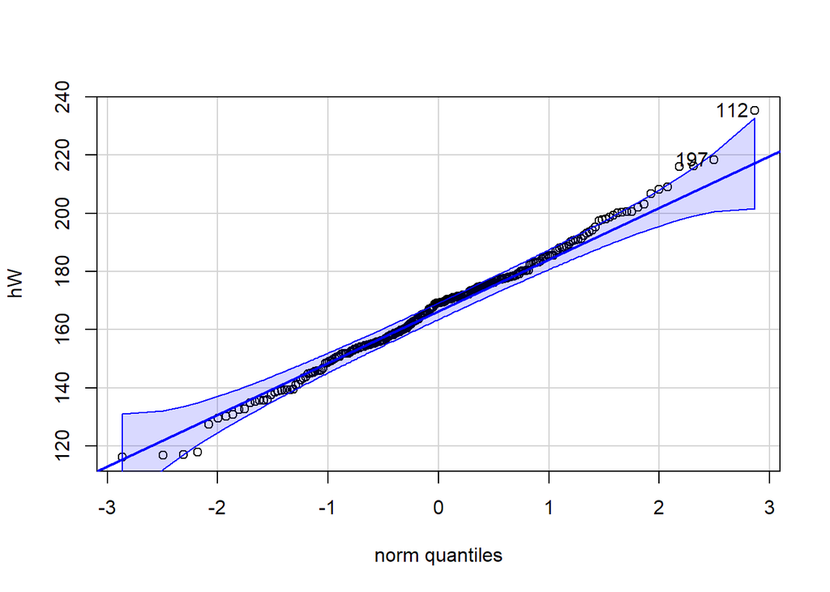

```
## [1] 112 197
```

```r
hW <- df[df$gender=="woman",]$height
hM <- df[df$gender=="man",]$height

qqPlot(hW)
```

```r
shapiro.test(hW)
```

```
##
##  Shapiro-Wilk normality test
##
## data:  hW
## W = 0.99402, p-value = 0.4613
```

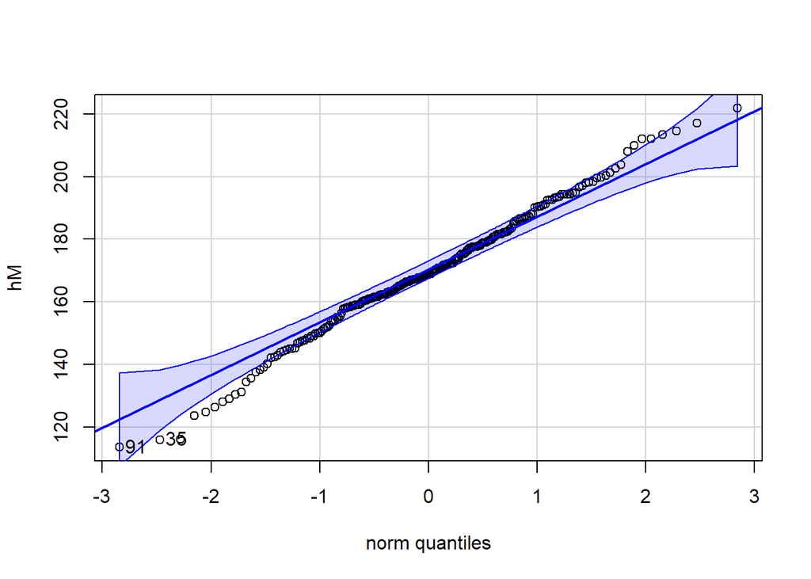

```
## [1] 91 35
```

```r
qqPlot(hM)
```

```r
shapiro.test(hM)
```

```
##
##  Shapiro-Wilk normality test
##
## data:  hM
## W = 0.99298, p-value = 0.3721
```

P-value dla obu grup jest większe niż 0.1, więc możemy założyć, że obie grupy dla zmiennej height mają rozkład normalny.

```r
n <- length(hM)
m <- length(hW)
alpha <- 0.01
#unbiased variance estimators
unbiased_estX <- 1/(n-1)*sum((hM-mean(hM))^2)
unbiased_estY <- 1/(m-1)*sum((hW-mean(hW))^2)

a <- unbiased_estX/n + unbiased_estY/m
t <- (mean(hM) - mean(hW))/sqrt(a) #test statistic

def <- a^2/(1/(n-1)*(unbiased_estX/n)^2+1/(m-1)*(unbiased_estY/m)^2) #deg of freedom

#two-tailed hypothesis
pval <- 2*pt(t, n+m-2, lower.tail = FALSE)

#confidence interval
lowerBound <- qt(alpha/2, n+m-2)
upperBound <- qt(1-alpha/2, n+m-2)

if(alpha > pval) {
  print("H0 rejected.")
}else {
  print("There is not enough evidence to reject H_0")
}
```

```
## [1] "There is not enough evidence to reject H_0"
```

```r
sprintf("test statistic = %f , p-value=%f, confidence interval = (%f, %f)", t, pval, lowerBound, upperBound)
```

```
## [1] "test statistic = 1.309895 , p-value=0.190885, confidence interval = (-2.586559, 2.586559)"
```

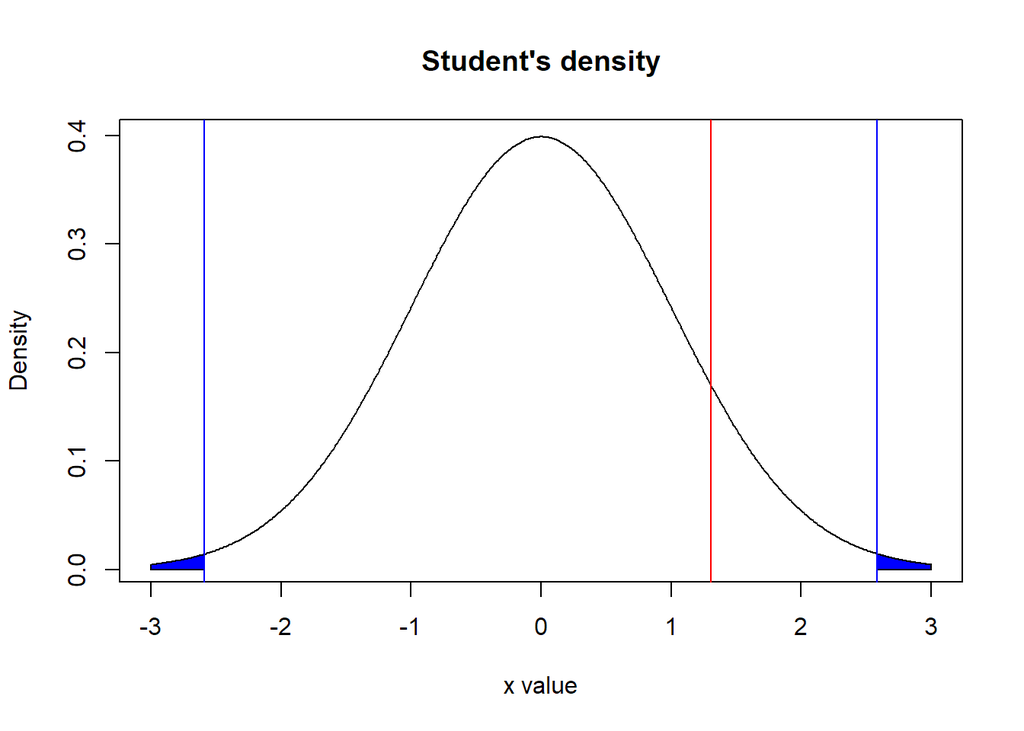

```r
x <- seq(-3, 3, by = 0.01)
t_dense <- dt(x, n+m-2)

plot(x, t_dense,type='l', xlab="x value",
  ylab="Density", main="Student's density")

i <- x >= lowerBound & x <= upperBound
lines(x, t_dense)

polygon(x = c(-3, seq(-3, lowerBound, 0.01), lowerBound),
        y = c(0, dt(seq(-3, lowerBound, 0.01),n+m-2), 0),
        col = 'blue')

polygon(x = c(upperBound, seq(upperBound, 3, 0.01), 3),
        y = c(0, dt(seq(upperBound, 3, 0.01), n+m-2), 0),
        col = 'blue')

area <- pt(upperBound, n+m-2) - pt(lowerBound, n+m-2)
abline(v=t, col="red")
abline(v=lowerBound, col="blue")
abline(v=upperBound, col="blue")
```

Nie ma powodów do odrzucenia hipotezy zerowej - statystyka testowa nie wpada do obszaru krytycznego. Średni wzrost dla kobiet nie różni się od średniego wzrostu dla mężczyzn.

## 5.2 Zależność między dwiema zmiennymi ilościowymi.

Współczynnik korelacji Pearsona: (posłużę się gotową implementacją)

Hipoteza zerowa $H_0$: Zmienne nie są skorelowane $\rho = 0$.  
Hipoteza alternatywna $H_1$: Zmienne są skorelowane $\rho \neq 0$.  
Założenia: (zmienne mają rozkład normalny, zależność liniowa między zmiennymi)

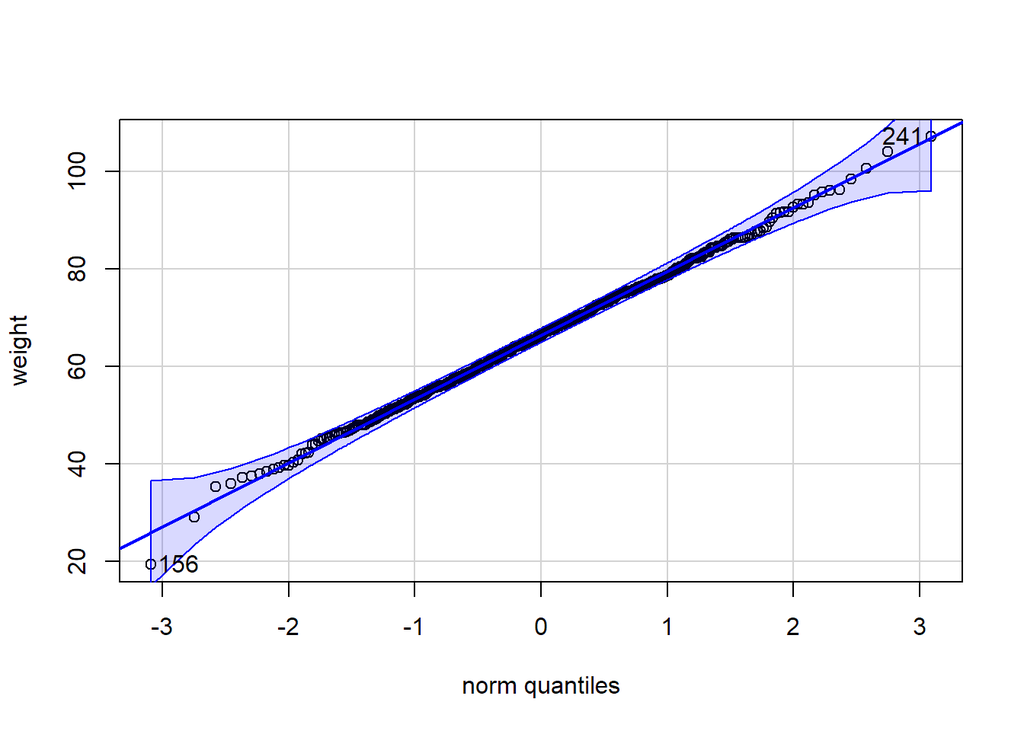

```
## [1] 156 241
```

```r
weight <- df$weight
height <- df$height

alpha <- 0.01

qqPlot(weight)
```

```r
shapiro.test(weight)
```

```
##
##  Shapiro-Wilk normality test
##
## data:  weight
## W = 0.99895, p-value = 0.9939
```

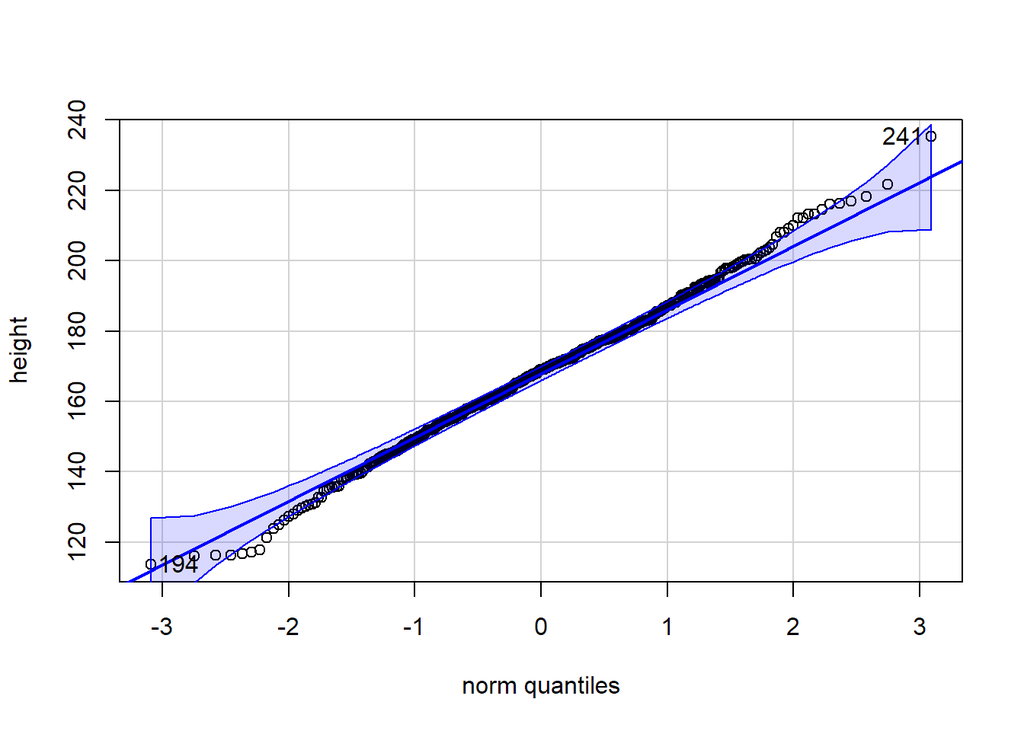

```
## [1] 241 194
```

```r
qqPlot(height)
```

```r
shapiro.test(height)
```

```
##
##  Shapiro-Wilk normality test
##
## data:  height
## W = 0.99662, p-value = 0.3778
```

Widzimy, że zmienne mają rozkład normalny (duże p-value z testu Shapiro-Wilka + wygląd wykresów qqPlot()).

**Scatterplot - zależność między zmiennymi**:

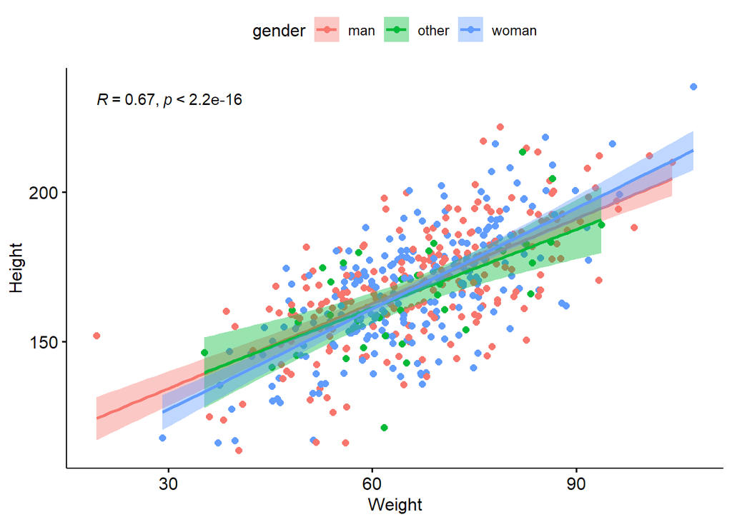

```r
p1 <- ggscatter(df, x = "weight", y = "height",
          add = "reg.line", conf.int = TRUE,
          cor.coef = TRUE, cor.method = "pearson", color="gender",
          xlab = "Weight", ylab = "Height")
p1
```

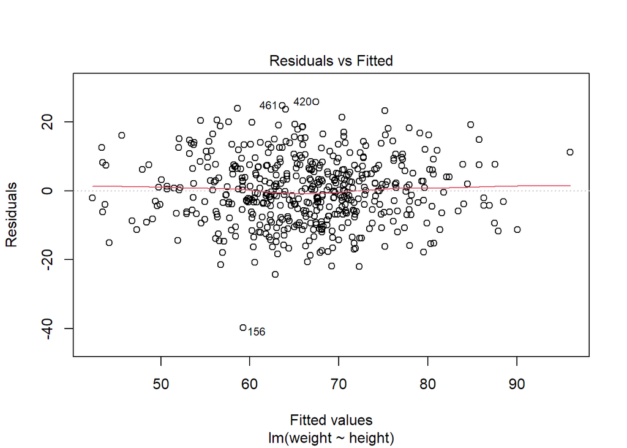

```r
linearity_test <- lm(weight~height, df)
plot(linearity_test, which=1)
```

```r
#summary(linearity_test)
```

Liniowa zależność między zmiennymi weight i height - założenie spełnione.

```r
test <- cor.test(x=weight, y=height, method="pearson", alternative = "two.sided", conf.level = 1-alpha)
sprintf("test statistic = %f , p-value=%f, confidence interval = (%f, %f), cor = %f", test$statistic, test$p.value, test$conf.int[1], test$conf.int[2], test$estimate)
```

```
## [1] "test statistic = 20.123937 , p-value=0.000000, confidence interval = (0.600957, 0.728596), cor = 0.669693"
```

```r
if (alpha > test$p.value) {
  print("H0 rejected.")
}else {
  print("There is not enough evidence to reject H_0")
}
```

```
## [1] "H0 rejected."
```

P-value wynosi mniej niż ustalony poziom istotności 0.01 - odrzucamy hipotezę zerową. Możemy zatem wywnioskować, że zmienne weight i height **są istotnie skorelowane** co potwierdza wcześniejszy korelogram z pierwszego podpunktu.

## 5.3 Zależność między dwiema zmiennymi ilościowymi.

Wykorzystam funkcję napisaną wcześniej.

Hipoteza zerowa $H_0$: Zmienne są **niezależne**.  
Hipoteza alternatywna $H_1$: Zmienne są **zależne**.  
Założenia: zmienne wzajemnie się wykluczają - spełnione.

```r
alpha <- 0.01
g <- testchi(df$married, df$number_of_kids, sq=205, t='married/number_of_kids', alpha = alpha)
```

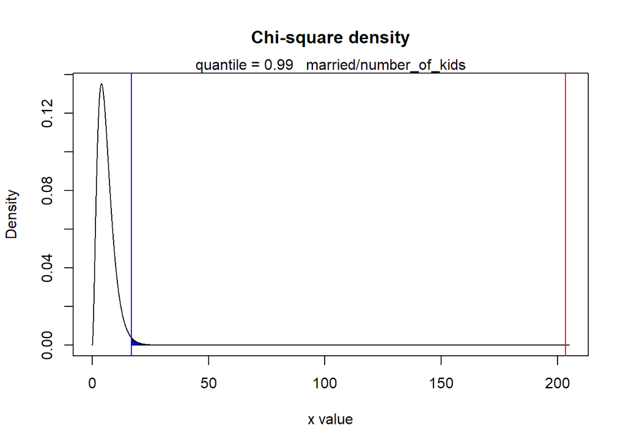

```r
sprintf("KIDS/MARRIED, test statistic = %f , p-value = %f, confidece interval = [-infinity, %f]", g[[1]], g[[2]], g[[3]])
```

```
## [1] "KIDS/MARRIED, test statistic = 203.501380 , p-value = 0.000000, confidece interval = [-infinity, 16.811894]"
```

Odrzucamy hipotezę zerową, wartość statystyki testowej wpada do obszaru krytycznego. Zmienne married i number_of_kids są zależne.

## 5.4 Hipoteza o zgodności z konkretnym rozkładem parametrycznym

Przeprowadzę test dla zmiennej number_of_kids.  
Niech zmienna X ma rozkład Pascala z parametrami $p=0.7$ i $r=5$. Przyjmijmy jedną zmienną jako wartość oczekiwaną a drugą jako obserwację dla testu chi2.  
Hipoteza zerowa $H_0$: Zmienne są niezależne.  
Hipoteza alternatywna $H_1$: Zmienne **nie** są niezależne.  
Założenia: zmienne wzajemnie się wykluczają - spełnione.

```r
kids <- df$number_of_kids
x <- rnbinom(length(kids), 5, 0.7)
x <- factor(x)
yf <- testchi(kids, x, sq=150, t=' ', alpha=alpha)
```

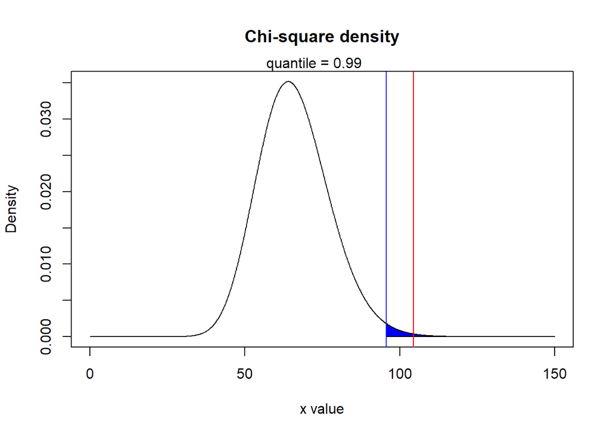

```r
sprintf("KIDS/MARRIED, test statistic = %f , p-value = %f, confidece interval = [-infinity, %f]", yf[[1]], yf[[2]], yf[[3]])
```

```
## [1] "KIDS/MARRIED, test statistic = 104.466178 , p-value = 0.001796, confidece interval = [-infinity, 95.625719]"
```

# 6 Regresja liniowa

**6.** **Oszacuj model regresji liniowej, przyjmując za zmienną zależną (y) wydatki domowe (expenses) a jako zmienne niezależne (x) przyjmując pozostałe zmienne.**  
Rozważ, czy konieczne są transformacje zmiennych lub zmiennej objaśnianej. Podaj **RSS**, **R^2**, **p-wartości** i **oszacowania współczynników w pełnym modelu** (w modelu zawierającym wszystkie zmienne). Następnie wybierz jedną zmienną objaśniającą, którą można by z pełnego modelu odrzucić (która najgorzej tłumaczy expenses). Aby dokonać wyboru takiej zmiennej, dla każdej ze zmiennych objaśniających sprawdź:  
- Jaką ma p-wartość w pełnym modelu?  
- O ile zmniejsza się R^2, gdy ją usuniemy z pełnego modelu?  
- O ile zwiększa się RSS, gdy ją usuniemy z pełnego modelu?  
Opisz wnioski.  
Oszacuj model ze zbiorem zmiennych objaśniających pomniejszonym o wybraną zmienną. Sprawdź czy w otrzymanym przez Ciebie modelu spełnione są założenia modelu liniowego i przedstaw na wykresach diagnostycznych: wykresie zależności reszt od zmiennej objaśnianej, na wykresie reszt studentyzowanych i na wykresie dźwigni i przedyskutuj, czy są spełnione.

Do tego zadania konieczne będzie zamiana zmiennych kategorycznych funkcją factor()- zrobiłam to już wcześniej przy okazji wczytywania danych. W przeciwnym razie zmienna np. number_of_kids mogłaby zostać potraktowana przez funkcję lm() jako zmienna ilościowa.

## 6.1 Pełny model bez zmian

```r
linear_regression <- lm( expenses ~ age + weight + height + gender + married + number_of_kids + pet, df)
summary(linear_regression)
```

```
##
## Call:
## lm(formula = expenses ~ age + weight + height + gender + married +
##     number_of_kids + pet, data = df)
##
## Residuals:
##     Min      1Q  Median      3Q     Max
## -758.69 -119.55    3.06  128.17  885.29
##
## Coefficients:
##                   Estimate Std. Error t value Pr(>|t|)
## (Intercept)     -2299.7769   101.8435 -22.581  < 2e-16 ***
## age                57.5620     1.0753  53.529  < 2e-16 ***
## weight              1.3272     0.9963   1.332  0.18345
## height              2.0825     0.6572   3.169  0.00163 **
## genderother        48.1590    37.7395   1.276  0.20254
## genderwoman       -17.6926    20.1808  -0.877  0.38108
## marriedTRUE       -17.7722    26.3260  -0.675  0.49995
## number_of_kids1    14.9060    25.9026   0.575  0.56525
## number_of_kids2   -56.9082    30.1096  -1.890  0.05935 .
## number_of_kids3    25.9653    38.2434   0.679  0.49750
## number_of_kids4   -52.4638    46.6479  -1.125  0.26129
## number_of_kids5   -31.8876    72.4424  -0.440  0.66000
## number_of_kids6  -115.3335    93.2361  -1.237  0.21669
## petdog             34.8071    30.1051   1.156  0.24818
## petferret         413.5364    36.2367  11.412  < 2e-16 ***
## pethedgehog       244.8257    35.8244   6.834  2.5e-11 ***
## petnone            24.2985    26.1476   0.929  0.35321
## ---
## Signif. codes:  0 '***' 0.001 '**' 0.01 '*' 0.05 '.' 0.1 ' ' 1
##
## Residual standard error: 212.9 on 483 degrees of freedom
## Multiple R-squared:  0.8637, Adjusted R-squared:  0.8592
## F-statistic: 191.3 on 16 and 483 DF,  p-value: < 2.2e-16
```

```r
mean(linear_regression$residuals) #wartość średnia reszty
```

```
## [1] 8.637813e-16
```

## 6.2 Prawidłowość formy funkcyjnej

Prawidłowość formy funkcyjnej modelu weryfikujemy, wykorzystując test RESET (Regression Specification Error Test) Ramseya.

Test polega na tym, że do modelu przeprowadza się regresję pomocniczą z dodanymi iloczynami zm. objaśniających po czym testem F sprawdzamy łączną istotność tych dodatkowych członów.  
Hipoteza zerowa $H_0$: $X\beta+\epsilon$.  
Hipoteza alternatywna $H_1$: $f(X\beta)+\epsilon$.

```r
resettest(linear_regression, power=2:6, type = c("fitted", "regressor", "princomp"))
```

```
##
##  RESET test
##
## data:  linear_regression
## RESET = 19.441, df1 = 5, df2 = 478, p-value < 2.2e-16
```

Nieliniowość w danych, residua nie są rozrzucone równo wokół 0:

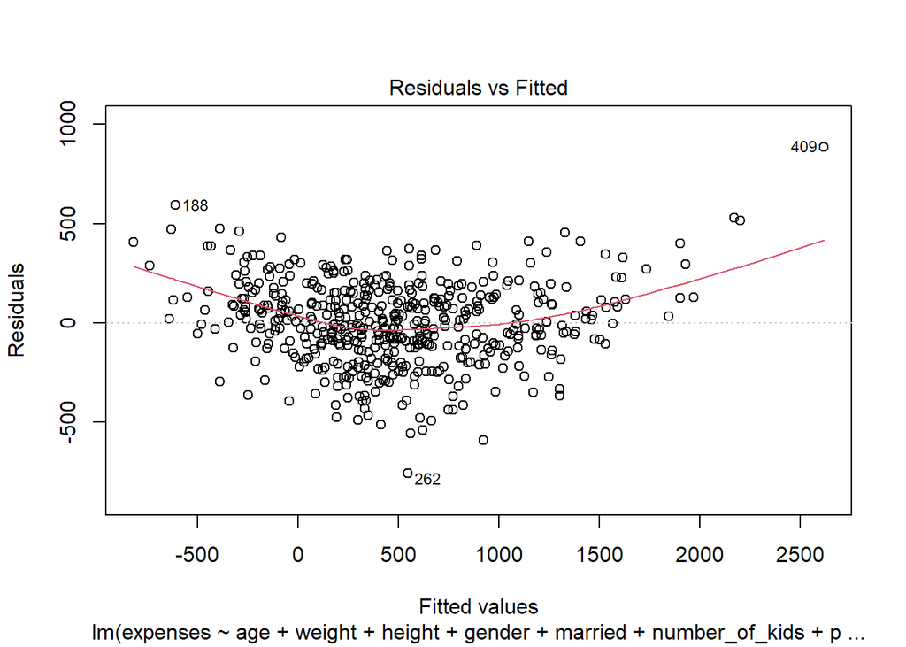

```r
plot(linear_regression, which = 1)
```

Przedziały ufności:

```r
confint(linear_regression,level = 0.99)
```

```
##                         0.5 %       99.5 %
## (Intercept)     -2563.1487967 -2036.404917
## age                54.7811353    60.342913
## weight             -1.2493246     3.903807
## height              0.3830433     3.781893
## genderother       -49.4370254   145.754985
## genderwoman       -69.8809813    34.495869
## marriedTRUE       -85.8523275    50.307948
## number_of_kids1   -52.0793817    81.891433
## number_of_kids2  -134.7730157    20.956701
## number_of_kids3   -72.9339491   124.864596
## number_of_kids4  -173.0974669    68.169920
## number_of_kids5  -219.2271101   155.451881
## number_of_kids6  -356.4464843   125.779531
## petdog            -43.0461111   112.660369
## petferret         319.8266502   507.246079
## pethedgehog       152.1820547   337.469348
## petnone           -43.3205144    91.917542
```

**Regresja liniowa na pełnym modelu**: Oszacowania współczynników (Estimate)

```r
linear_regression$coefficients
```

```
##     (Intercept)             age          weight          height     genderother
##    -2299.776857       57.562024        1.327241        2.082468       48.158980
##     genderwoman     marriedTRUE number_of_kids1 number_of_kids2 number_of_kids3
##      -17.692556      -17.772190       14.906026      -56.908157       25.965324
## number_of_kids4 number_of_kids5 number_of_kids6          petdog       petferret
##      -52.463774      -31.887615     -115.333476       34.807129      413.536364
##     pethedgehog         petnone
##      244.825701       24.298514
```

Residual sum of squares (RSS):

```r
RSS <- sum(resid(linear_regression)^2)
print(RSS)
```

```
## [1] 21901205
```

Współczynnik determinacji (R^2):

```r
R2 <- summary(linear_regression)$r.squared
print(round(R2, 3))
```

```
## [1] 0.864
```

P-wartości w pełnym modelu dla zmiennych:

```r
summary(linear_regression)$coefficients[,4]
```

```
##     (Intercept)             age          weight          height     genderother
##    1.323336e-77   3.311685e-205    1.834474e-01    1.627050e-03    2.025367e-01
##     genderwoman     marriedTRUE number_of_kids1 number_of_kids2 number_of_kids3
##    3.810836e-01    4.999464e-01    5.652457e-01    5.935204e-02    4.974956e-01
## number_of_kids4 number_of_kids5 number_of_kids6          petdog       petferret
##    2.612852e-01    6.600046e-01    2.166867e-01    2.481765e-01    7.146571e-27
##     pethedgehog         petnone
##    2.497126e-11    3.532076e-01
```

Variance inflation factor (VIF) - mierzy o ile wariancja oszacowanego współczynnika regresji jest zwiększona z powodu kolinearności.

```r
vif(linear_regression)
```

```
##                    GVIF Df GVIF^(1/(2*Df))
## age            1.025355  1        1.012598
## weight         1.831392  1        1.353289
## height         1.836310  1        1.355105
## gender         1.055675  2        1.013637
## married        1.729303  1        1.315030
## number_of_kids 1.871981  6        1.053639
## pet            1.070701  4        1.008576
```

```r
mean(vif(linear_regression))
```

```
## [1] 1.644409
```

## 6.3 One-Hot Encoding

Funkcja lm() sama przekształciła zmienne kategoryczne. Jednak żeby usunąć, którąś z takich zakodowanych zmiennych należy wcześniej je samodzielnie zakodować. Funkcja one_hot() z biblioteki mltools przekształca zmienną kategoryczną metodą One-Hot Encoding bez odrzucania żadnych kolumn bazowych. Do modelu linear_regression2 nie wprowadzono poziomów gender_woman, married_FALSE, number_of_kids_1, pet_none (najczęściej występujące w swoich kategorycznych zmiennych) - żeby nie wprowadzać zmiennych, które wiadomo, że będą skorelowane.

```r
df_ohe <- one_hot(as.data.table(df), dropUnusedLevels=TRUE) #cols DEFAULT = "auto" encodes all unordered factor columns
head(df_ohe)
```

```
##    age weight height gender_man gender_other gender_woman married_FALSE
## 1:  25   61.7 121.12          0            1            0             1
## 2:  37   63.9 145.00          1            0            0             0
## 3:  41   50.2 145.03          0            0            1             0
## 4:  43   72.4 179.90          1            0            0             1
## 5:  26   78.4 163.91          1            0            0             1
## 6:  49   59.4 151.86          0            0            1             0
##    married_TRUE number_of_kids_0 number_of_kids_1 number_of_kids_2
## 1:            0                0                0                1
## 2:            1                0                0                0
## 3:            1                0                0                1
## 4:            0                0                1                0
## 5:            0                0                1                0
## 6:            1                0                0                1
##    number_of_kids_3 number_of_kids_4 number_of_kids_5 number_of_kids_6 pet_cat
## 1:                0                0                0                0       0
## 2:                0                0                0                1       0
## 3:                0                0                0                0       0
## 4:                0                0                0                0       0
## 5:                0                0                0                0       0
## 6:                0                0                0                0       0
##    pet_dog pet_ferret pet_hedgehog pet_none   expenses
## 1:       0          1            0        0   23.44299
## 2:       1          0            0        0   96.83683
## 3:       0          0            1        0  312.67693
## 4:       1          0            0        0  447.42838
## 5:       0          0            1        0  -78.22799
## 6:       0          1            0        0 1241.98263
```

```r
linear_regression2 <- lm(expenses~.-gender_woman-married_FALSE-number_of_kids_1-pet_none, df_ohe)
summary(linear_regression2)
```

```
##
## Call:
## lm(formula = expenses ~ . - gender_woman - married_FALSE - number_of_kids_1 -
##     pet_none, data = df_ohe)
##
## Residuals:
##     Min      1Q  Median      3Q     Max
## -758.69 -119.55    3.06  128.17  885.29
##
## Coefficients:
##                    Estimate Std. Error t value Pr(>|t|)
## (Intercept)      -2278.2649    97.5326 -23.359  < 2e-16 ***
## age                 57.5620     1.0753  53.529  < 2e-16 ***
## weight               1.3272     0.9963   1.332  0.18345
## height               2.0825     0.6572   3.169  0.00163 **
## gender_man          17.6926    20.1808   0.877  0.38108
## gender_other        65.8515    37.5648   1.753  0.08023 .
## married_TRUE       -17.7722    26.3260  -0.675  0.49995
## number_of_kids_0   -14.9060    25.9026  -0.575  0.56525
## number_of_kids_2   -71.8142    27.8767  -2.576  0.01029 *
## number_of_kids_3    11.0593    35.5787   0.311  0.75606
## number_of_kids_4   -67.3698    44.3679  -1.518  0.12956
## number_of_kids_5   -46.7936    70.5569  -0.663  0.50752
## number_of_kids_6  -130.2395    92.0909  -1.414  0.15793
## pet_cat            -24.2985    26.1476  -0.929  0.35321
## pet_dog             10.5086    26.5640   0.396  0.69258
## pet_ferret         389.2379    33.1680  11.735  < 2e-16 ***
## pet_hedgehog       220.5272    33.0630   6.670 7.02e-11 ***
## ---
## Signif. codes:  0 '***' 0.001 '**' 0.01 '*' 0.05 '.' 0.1 ' ' 1
##
## Residual standard error: 212.9 on 483 degrees of freedom
## Multiple R-squared:  0.8637, Adjusted R-squared:  0.8592
## F-statistic: 191.3 on 16 and 483 DF,  p-value: < 2.2e-16
```

-Duże pvalue pet_dog i number_of_kids_3 (nieistotne statystycznie - duże pvalue).  
-Stała okazała się istotna statystycznie (pval < 2e-16 …)  
-Podobnie age (< 2e-16 …), height(< 0.00163 .. ), number_of_kids_2 (< 0.01029 .), pet_ferret (< 2e-16 …), pet_hedgehog ( < 7.02e-11 …)  
-Zmienne są łącznie istotne statystycznie - pval <2.2e-16 w teście F

Residual sum of squares (RSS):

```r
RSS <- sum(resid(linear_regression2)^2)
print(RSS)
```

```
## [1] 21901205
```

Współczynnik determinacji (R^2):

```r
R2 <- summary(linear_regression2)$r.squared
print(round(R2, 3))
```

```
## [1] 0.864
```

```r
summary(linear_regression2)$coefficients[,4]
```

```
##      (Intercept)              age           weight           height
##     2.557938e-81    3.311685e-205     1.834474e-01     1.627050e-03
##       gender_man     gender_other     married_TRUE number_of_kids_0
##     3.810836e-01     8.023463e-02     4.999464e-01     5.652457e-01
## number_of_kids_2 number_of_kids_3 number_of_kids_4 number_of_kids_5
##     1.028706e-02     7.560560e-01     1.295589e-01     5.075161e-01
## number_of_kids_6          pet_cat          pet_dog       pet_ferret
##     1.579329e-01     3.532076e-01     6.925777e-01     3.739870e-28
##     pet_hedgehog
##     7.021587e-11
```

## 6.4 R^2 i RSS po usunięciu zmiennych

**O ile zmniejsza się R^2, gdy usuniemy zmienną z pełnego modelu?**  
**O ile zwiększa się RSS, gdy usuniemy zmienną z pełnego modelu?**  
Bedziemy odrzucać po jednej zmiennej z pełnego modelu i patrzeć jak bardzo zmienia się R^2 i RSS:

```r
df_ohe <- data.table(df_ohe)

features <- c("age", "weight", "height", "gender_other", "gender_man", "married_TRUE", "number_of_kids_6", "number_of_kids_0", "number_of_kids_2",
            "number_of_kids_3", "number_of_kids_4", "number_of_kids_5", "pet_cat", "pet_dog", "pet_ferret", "pet_hedgehog")
df_features <- df_ohe[, c("age", "weight", "height", "gender_other", "gender_man", "married_TRUE", "number_of_kids_6", "number_of_kids_0", "number_of_kids_2",
            "number_of_kids_3", "number_of_kids_4", "number_of_kids_5", "pet_cat", "pet_dog", "pet_ferret", "pet_hedgehog", "expenses")]

rsq <- NULL
rsss <- NULL
i<-1
for(c in features) {
  fo <- as.formula(paste("expenses", "~.-", c))
  r <- do.call("lm", list(fo, quote(df_features)))
  rsq[i] <- summary(r)$r.squared
  rsss[i] <- sum(resid(r)^2)
  i <- i+1
}

R <- data.frame(features, rsq, rep(R2, length(features))-rsq, rsss, rsss-rep(RSS, length(features)))
colnames(R) <- c("deleted_column", "R_2", "difference_R2", "RSS", "difference_RSS")
R2ord <- R[order(R$difference_R2), ]
R2ord
```

```
##      deleted_column        R_2 difference_R2       RSS difference_RSS
## 10 number_of_kids_3 0.86367537  2.726562e-05  21905586   4.381229e+03
## 14          pet_dog 0.86365847  4.416154e-05  21908301   7.096182e+03
## 8  number_of_kids_0 0.86360918  9.344936e-05  21916221   1.501609e+04
## 12 number_of_kids_5 0.86357852  1.241181e-04  21921149   1.994415e+04
## 6      married_TRUE 0.86357403  1.286039e-04  21921870   2.066496e+04
## 5        gender_man 0.86348574  2.168931e-04  21936057   3.485189e+04
## 13          pet_cat 0.86345895  2.436882e-04  21940363   3.915751e+04
## 2            weight 0.86320187  5.007606e-04  21981671   8.046569e+04
## 7  number_of_kids_6 0.86313823  5.644070e-04  21991898   9.069283e+04
## 11 number_of_kids_4 0.86305201  6.506286e-04  22005753   1.045475e+05
## 4      gender_other 0.86283545  8.671800e-04  22040550   1.393445e+05
## 9  number_of_kids_2 0.86182989  1.872746e-03  22202131   3.009257e+05
## 3            height 0.86086886  2.833778e-03  22356556   4.553510e+05
## 16     pet_hedgehog 0.85114867  1.255397e-02  23918463   2.017258e+06
## 15       pet_ferret 0.82484011  3.886253e-02  28145905   6.244700e+06
## 1               age 0.05513236  8.085703e-01 151827880   1.299267e+08
```

```r
RSSord <- R[order(R$difference_RSS), ]
RSSord
```

```
##      deleted_column        R_2 difference_R2       RSS difference_RSS
## 10 number_of_kids_3 0.86367537  2.726562e-05  21905586   4.381229e+03
## 14          pet_dog 0.86365847  4.416154e-05  21908301   7.096182e+03
## 8  number_of_kids_0 0.86360918  9.344936e-05  21916221   1.501609e+04
## 12 number_of_kids_5 0.86357852  1.241181e-04  21921149   1.994415e+04
## 6      married_TRUE 0.86357403  1.286039e-04  21921870   2.066496e+04
## 5        gender_man 0.86348574  2.168931e-04  21936057   3.485189e+04
## 13          pet_cat 0.86345895  2.436882e-04  21940363   3.915751e+04
## 2            weight 0.86320187  5.007606e-04  21981671   8.046569e+04
## 7  number_of_kids_6 0.86313823  5.644070e-04  21991898   9.069283e+04
## 11 number_of_kids_4 0.86305201  6.506286e-04  22005753   1.045475e+05
## 4      gender_other 0.86283545  8.671800e-04  22040550   1.393445e+05
## 9  number_of_kids_2 0.86182989  1.872746e-03  22202131   3.009257e+05
## 3            height 0.86086886  2.833778e-03  22356556   4.553510e+05
## 16     pet_hedgehog 0.85114867  1.255397e-02  23918463   2.017258e+06
## 15       pet_ferret 0.82484011  3.886253e-02  28145905   6.244700e+06
## 1               age 0.05513236  8.085703e-01 151827880   1.299267e+08
```

Najmniejsza różnica w R^2 i RSS (3 i 5 kolumna) dla number_of_kids_3 (+duże pvalue w regresji liniowej)

## 6.5 Usunięcie zmiennej najgorzej tłumaczącej expenses

```r
#wyrzucam dodatkowo number_of_kids_3
linear_regression3 <- lm(expenses ~.-number_of_kids_1-married_TRUE-gender_woman-pet_none-number_of_kids_3, df_ohe)
summary(linear_regression3)
```

```
##
## Call:
## lm(formula = expenses ~ . - number_of_kids_1 - married_TRUE -
##     gender_woman - pet_none - number_of_kids_3, data = df_ohe)
##
## Residuals:
##     Min      1Q  Median      3Q     Max
## -758.47 -119.27    2.59  129.27  883.45
##
## Coefficients:
##                    Estimate Std. Error t value Pr(>|t|)
## (Intercept)      -2289.6498    97.5110 -23.481  < 2e-16 ***
## age                 57.5719     1.0739  53.612  < 2e-16 ***
## weight               1.3274     0.9954   1.334  0.18298
## height               2.0749     0.6561   3.163  0.00166 **
## gender_man          17.7275    20.1616   0.879  0.37969
## gender_other        65.6605    37.5247   1.750  0.08079 .
## married_FALSE       14.1053    23.5129   0.600  0.54886
## number_of_kids_0   -16.9776    25.0072  -0.679  0.49752
## number_of_kids_2   -75.0262    25.8665  -2.901  0.00390 **
## number_of_kids_4   -72.5561    41.0727  -1.767  0.07794 .
## number_of_kids_5   -52.3030    68.2307  -0.767  0.44372
## number_of_kids_6  -135.8840    90.1985  -1.506  0.13259
## pet_cat            -24.3437    26.1228  -0.932  0.35186
## pet_dog             10.5283    26.5391   0.397  0.69176
## pet_ferret         389.1340    33.1354  11.744  < 2e-16 ***
## pet_hedgehog       220.4780    33.0317   6.675  6.8e-11 ***
## ---
## Signif. codes:  0 '***' 0.001 '**' 0.01 '*' 0.05 '.' 0.1 ' ' 1
##
## Residual standard error: 212.7 on 484 degrees of freedom
## Multiple R-squared:  0.8637, Adjusted R-squared:  0.8595
## F-statistic: 204.4 on 15 and 484 DF,  p-value: < 2.2e-16
```

### 6.5.1 Sprawdzanie założeń KMLR

W modelu jest stała, założenie o wartości oczekiwanej błędu losowego nie musi być sprawdzane.

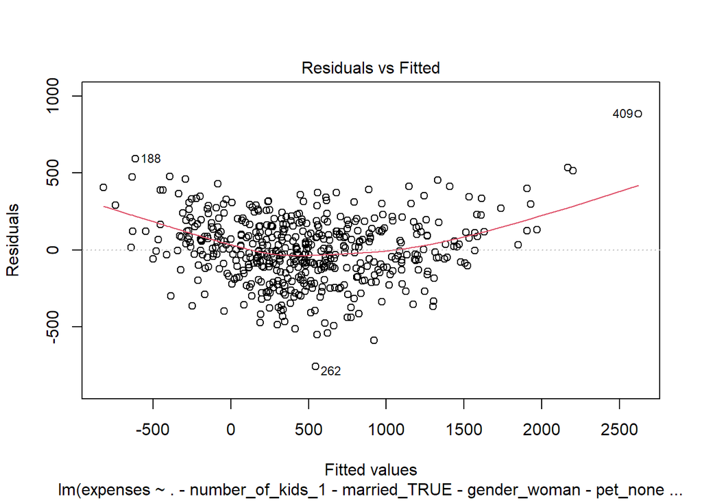

```r
plot(linear_regression3, which = 1)
```

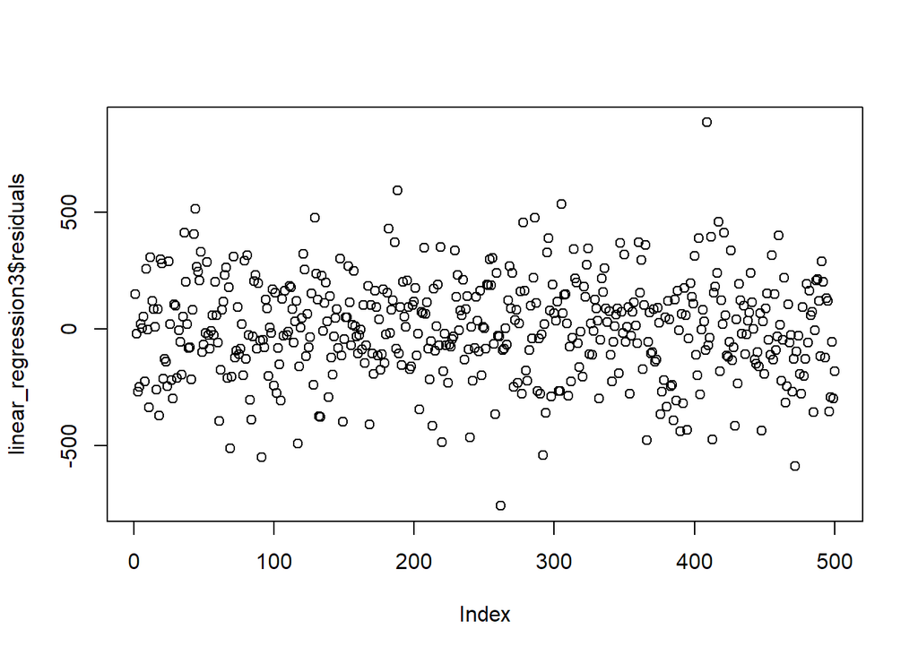

```r
plot(linear_regression3$residuals)
```

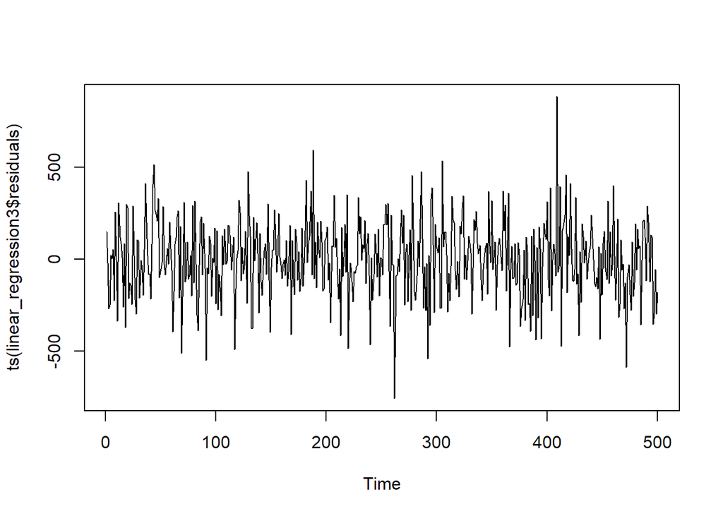

```r
plot(ts(linear_regression3$residuals))
```

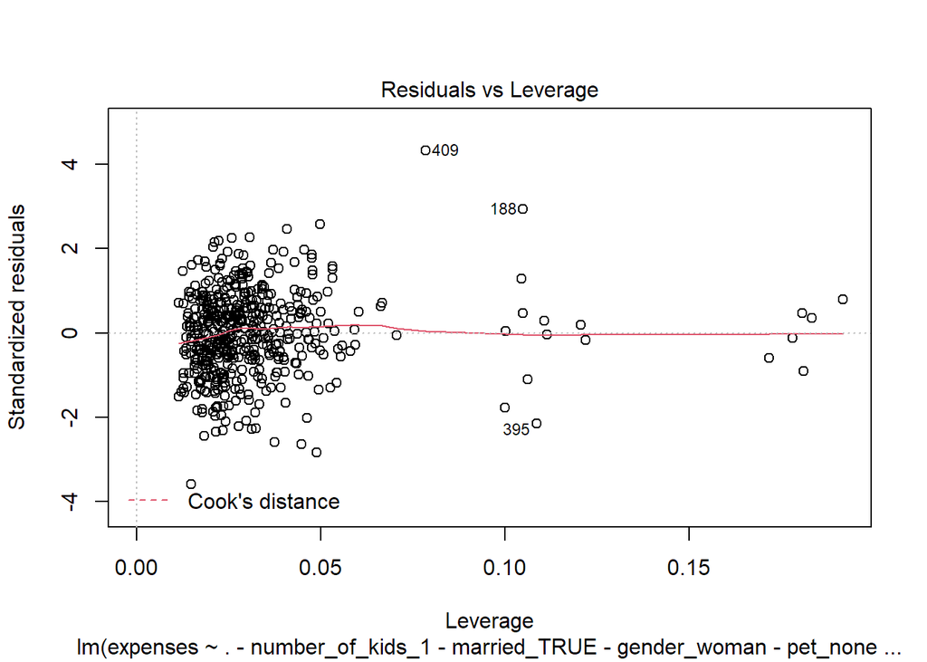

```r
plot(linear_regression3, which=5)
```

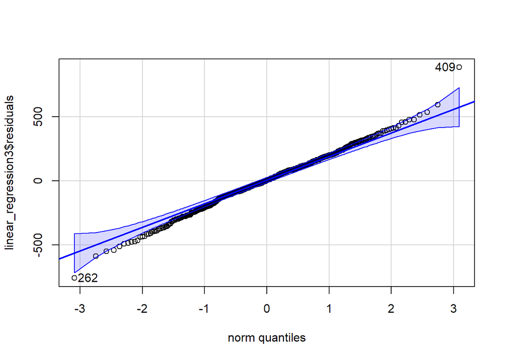

```
## [1] 409 262
```

```r
qqPlot(linear_regression3$residuals)
```

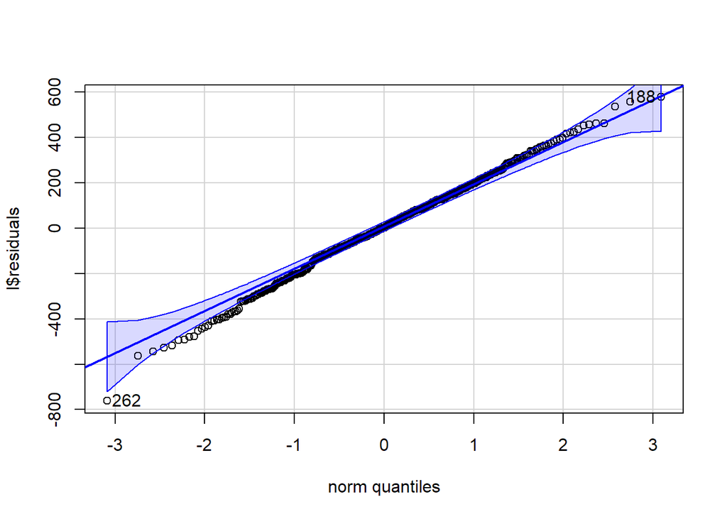

```
## [1] 262 188
```

```r
l <- lm(expenses ~.-number_of_kids_1-married_TRUE-gender_woman-pet_none-number_of_kids_3, df_ohe[c(-409),])
qqPlot(l$residuals)
```

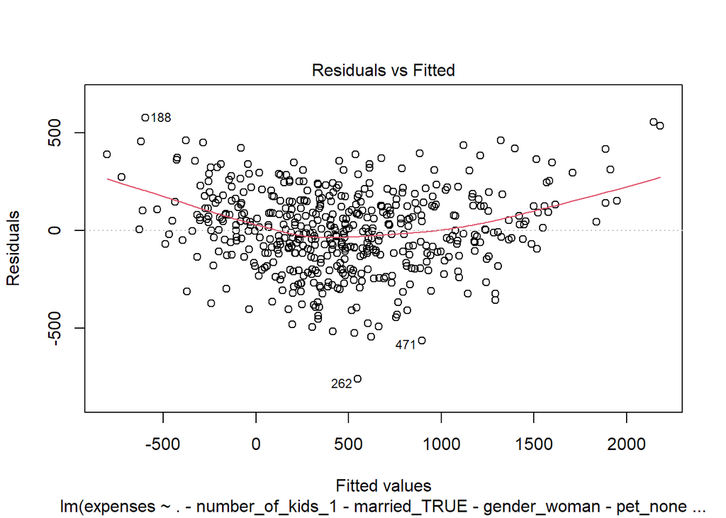

```r
plot(l, which = 1)
```

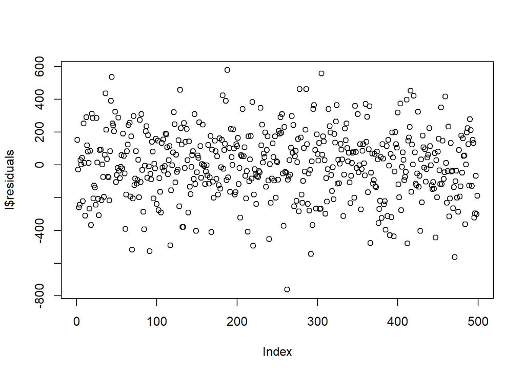

```r
plot(l$residuals)
```

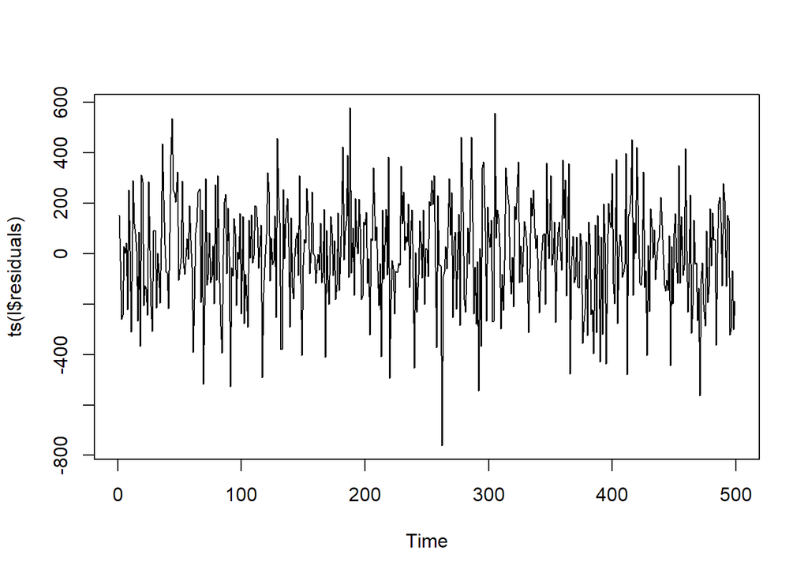

```r
plot(ts(l$residuals))
```

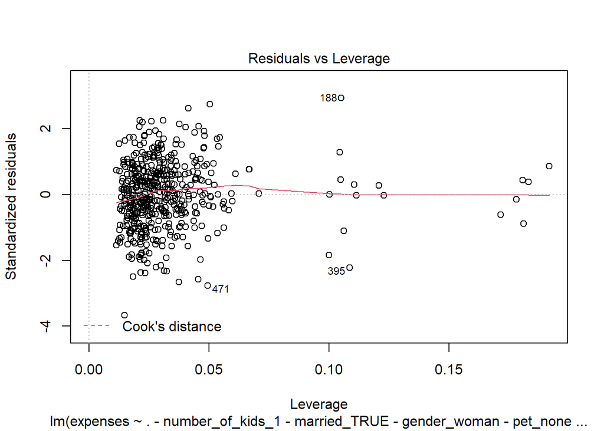

```r
plot(l, which=5)
```

### 6.5.2 Testy statystyczne

Normalność rozkładu reszt:

```r
shapiro.test(linear_regression3$residuals)
```

```
##
##  Shapiro-Wilk normality test
##
## data:  linear_regression3$residuals
## W = 0.99554, p-value = 0.1642
```

Pvalue większe niż 0.1 poziom istotności. Rozkład normalny reszt. Stałość wariancji (studentized Breusch-Pagan test):

```r
bptest(linear_regression3)
```

```
##
##  studentized Breusch-Pagan test
##
## data:  linear_regression3
## BP = 18.568, df = 15, p-value = 0.234
```